# Statistics for Ecologists

John Fieberg

07 January, 2025

Thank you for your interest in the Statistics for Ecologists book. The latest version (the first produced using quarto instead of bookdown) can be found [at this link](https://statistics4ecologists-v3.netlify.app/). I will be teaching with it for the first time this spring (2025). As with past editions, you can provide comments and correct errors using hypothes.is. Over the course of the next year, I will be working to improve accessibility (e.g., by adding alt-text to figures). I am sure there will be some minor kinks to work through as I am still learning quarto and tools for increasing accessibility.

Older archived versions of the book can be found at the URLs below:

- [Beta version](https://statistics4ecologistsbeta.netlify.app)
- [First version prior to publishing](https://statistics4ecologists-v1a.netlify.app/)
- [Second version, this is the first edition that was published as a pdf by University of Minnesota Library Publishing](https://statistics4ecologists-v2a.netlify.app/)

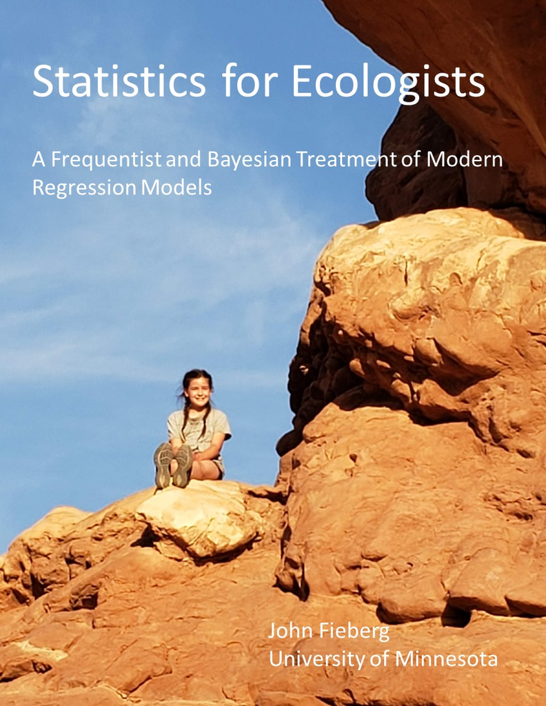

**Cover photograph**:  
Caroline Fieberg at Arches National Park, summer 2021. Photo taken by John Fieberg.  
**Suggested Citation:**  
Fieberg, John. (2024). Statistics for Ecologists: A Frequentist and Bayesian Treatment of Modern Regression Models. University of Minnesota Libraries Publishing. Retrieved from the University of Minnesota Digital Conservancy. https://doi.org/10.24926/9781959870029  
**License:**  
This work is licensed under a [Creative Commons Attribution 4.0 International License](http://creativecommons.org/licenses/by/4.0/).